# Part II - Ford GoBike System Data Analysis

## by Aaliyah Motala

## Investigation Overview

> The aim of this investigation is to analysis the Ford GoBike bikes data from February 2019, San Francisco, USA.  
> An complete analysis was carried out from assessing the data, cleaning and analysing.  
> My main was user types and gender.

## Dataset Overview

> The data included of the following variables:  
> Duration (seconds)  
> Start Time and Date  
> End Time and Date  
> Start Station ID  
> Start Station Name  
> Start Station Latitude  
> Start Station Longitude  
> End Station ID  
> End Station Name  
> End Station Latitude  
> End Station Longitude  
> Bike ID  
> User Type (Subscriber or Customer – “Subscriber” = Member or “Customer” = Casual)  
> Member Birth Year  
> Member Gender  
> Bike share for all

> Thereafter the data was analyzed and the final variables were:  
> Duration (seconds)  
> Duration (minutes) Start Time and Date  
> End Time and Date  
> Start Station ID  
> Start Station Name  
> End Station ID  
> End Station Name  
> User Type (Subscriber or Customer – “Subscriber” = Member or “Customer” = Casual)  
> Member Birth Year  
> Member Gender  
> Start day (day of week)  
> End day  
> Start hour  
> End hour  
> Member gender had "other" under gender which I removed  
> All null values were removed

## Percentage of users gender

> About 3/4 of users are Male

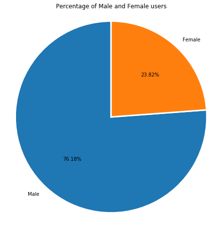

## Hours in which the bikes were rented the most

> 8am and 5pm were the times the bikes were most used.

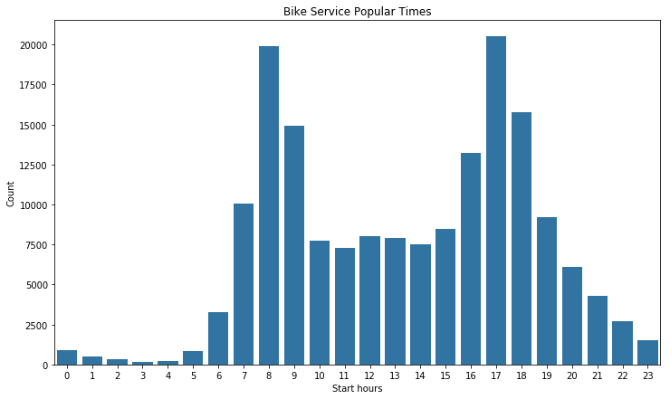

## Relationship between gender and user types

> Since males are 3/4 of users, its to be expected that males would dominate customers and subscribers

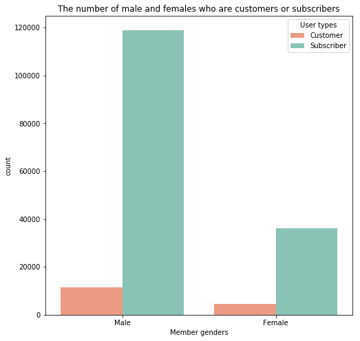

## Average trip duration for both genders and users

> Customers average bike duration is much higher than subcribers and females have a higher average bike duration than men

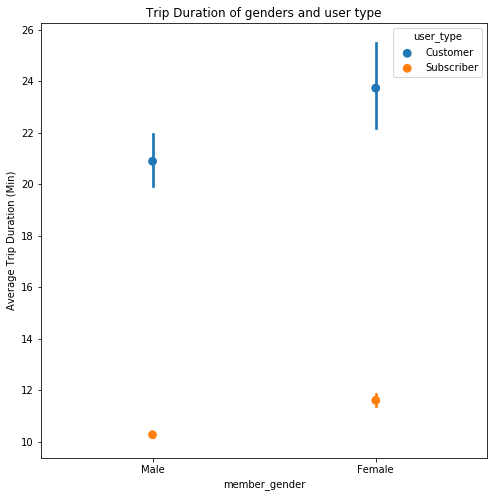